# 9 - Clustering

Joseph Rickert

Friday, August 29, 2014

In this script we will look at Kmeans and hierarchical clustering using the weather data.

[output not shown]

## Weather Data

```r
name <- "weather.csv"                  # name of the file
#dataDir <- getwd()                    # directory location
dataDir <- "C:/DATA/Rattle Data"
file <- file.path(dataDir,name)        # Construct the file path
weather <- read.csv(file)
#
weather <- weather[,-c(1,2)]           # Drop the first two columns
head(weather)                          # Look at the data
```

```
##   MinTemp MaxTemp Rainfall Evaporation Sunshine WindGustDir WindGustSpeed
## 1     8.0    24.3      0.0         3.4      6.3          NW            30
## 2    14.0    26.9      3.6         4.4      9.7         ENE            39
## 3    13.7    23.4      3.6         5.8      3.3          NW            85
## 4    13.3    15.5     39.8         7.2      9.1          NW            54
## 5     7.6    16.1      2.8         5.6     10.6         SSE            50
## 6     6.2    16.9      0.0         5.8      8.2          SE            44
##   WindDir9am WindDir3pm WindSpeed9am WindSpeed3pm Humidity9am Humidity3pm
## 1         SW         NW            6           20          68          29
## 2          E          W            4           17          80          36
## 3          N        NNE            6            6          82          69
## 4        WNW          W           30           24          62          56
## 5        SSE        ESE           20           28          68          49
## 6         SE          E           20           24          70          57
##   Pressure9am Pressure3pm Cloud9am Cloud3pm Temp9am Temp3pm RainToday
## 1        1020        1015        7        7    14.4    23.6        No
## 2        1012        1008        5        3    17.5    25.7       Yes
## 3        1010        1007        8        7    15.4    20.2       Yes
## 4        1006        1007        2        7    13.5    14.1       Yes
## 5        1018        1018        7        7    11.1    15.4       Yes
## 6        1024        1022        7        5    10.9    14.8        No
##   RISK_MM RainTomorrow
## 1     3.6          Yes
## 2     3.6          Yes
## 3    39.8          Yes
## 4     2.8          Yes
## 5     0.0           No
## 6     0.2           No
```

## KMEANS with plot and statistics

Note that the K means algorithm requires numeric variables

```r
numvars <- lapply(weather,is.numeric)           # Find numeric variables in data set
numdata <- na.omit(weather[,numvars==TRUE])
head(numdata)
```

```
##   MinTemp MaxTemp Rainfall Evaporation Sunshine WindGustSpeed WindSpeed9am
## 1     8.0    24.3      0.0         3.4      6.3            30            6
## 2    14.0    26.9      3.6         4.4      9.7            39            4
## 3    13.7    23.4      3.6         5.8      3.3            85            6
## 4    13.3    15.5     39.8         7.2      9.1            54           30
## 5     7.6    16.1      2.8         5.6     10.6            50           20
## 6     6.2    16.9      0.0         5.8      8.2            44           20
##   WindSpeed3pm Humidity9am Humidity3pm Pressure9am Pressure3pm Cloud9am
## 1           20          68          29        1020        1015        7
## 2           17          80          36        1012        1008        5
## 3            6          82          69        1010        1007        8
## 4           24          62          56        1006        1007        2
## 5           28          68          49        1018        1018        7
## 6           24          70          57        1024        1022        7
##   Cloud3pm Temp9am Temp3pm RISK_MM
## 1        7    14.4    23.6     3.6
## 2        3    17.5    25.7     3.6
## 3        7    15.4    20.2    39.8
## 4        7    13.5    14.1     2.8
## 5        7    11.1    15.4     0.0
## 6        5    10.9    14.8     0.2
```

```r
km <- kmeans(x=numdata, centers=3)
```

Generate a scatter plots of the variables colored by clusters

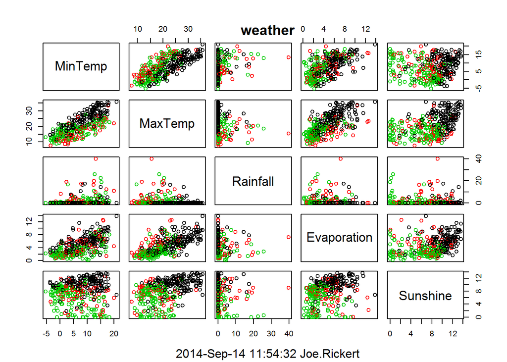

```r
vars <- 1:5
plot(numdata[vars], col=km$cluster)
title(main="weather",
    sub=paste(format(Sys.time(), "%Y-%b-%d %H:%M:%S"), Sys.info()["user"]))
```

Note that in the plot: “left” variable is on the y axis and the “under” variable is on the x axis

Next, we determine number of clusters by looking for a “knee” in the curve, i.e. the largest drop in the within sum of squares in the plot below

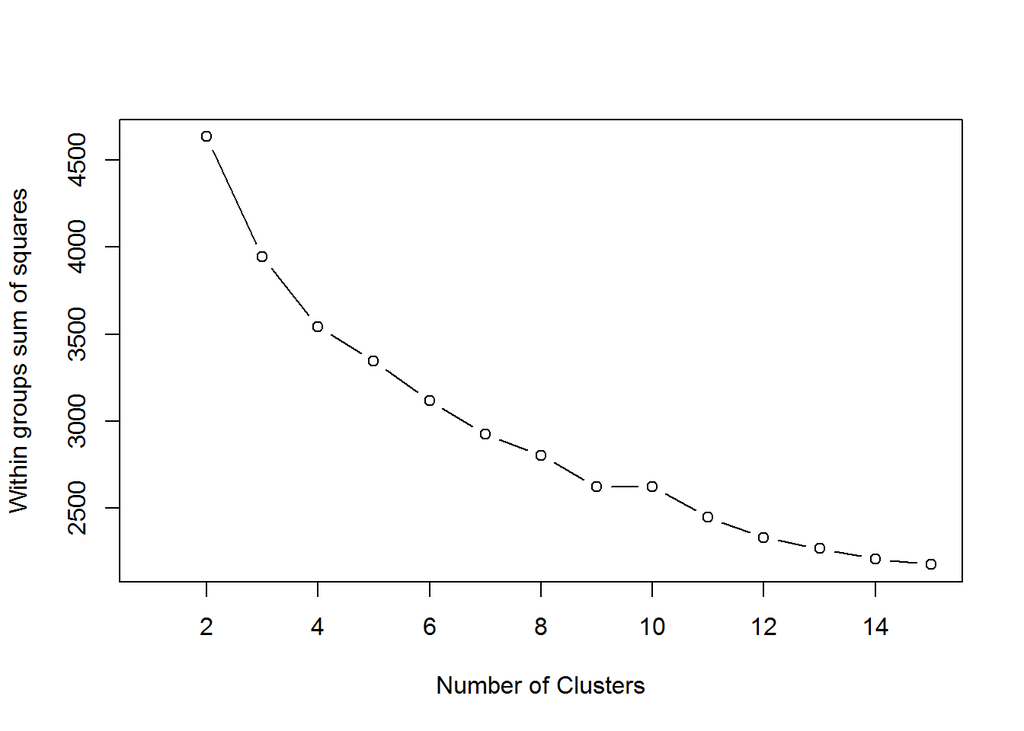

```r
numdataS <- scale(numdata)          # Scale the data: (x - m)/sd

ssPlot <- function(data,maxCluster=15){
                SSw  <- (nrow(data)-1)*sum(apply(data,2,var))   # Initialize within sum of squares
                SSw <- vector()
                  for (i in 2:maxCluster){
                         SSw[i] <- sum(kmeans(data,centers=i)$withinss)
                  }
                plot(1:maxCluster, SSw, type="b",
                             xlab="Number of Clusters",
                     ylab="Within groups sum of squares")
              }
ssPlot(numdataS)
```

The plotcluster function in the fpc package. There are parameters to distinguis classes by ten available projection methods, including classical discriminant coordinates, methods to project differences in mean and covariance structure, asymmetric methods (separation of a homogeneous class from a heterogeneous one), local neighborhood-based methods and methods based on robust covariance matrices. One-dimensional data is plotted against the cluster number.

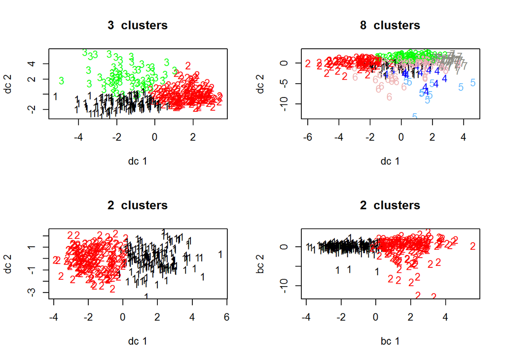

```r
kmPlot <- function(data,nclust=3,...)
        {
            km <- kmeans(x=data, centers=nclust)
            plotcluster(x=data,clvecd=km$cluster,...)            # plot fcn from fpc package
            title(main=paste(nclust, " clusters"))
            cluster.stats(dist(data),km$cluster)                 # Compute cluster stats with fcn from fpc package
            return(km)
        }

par(mfrow=c(2,2))
kmod <- kmPlot(numdataS)
kmod8 <- kmPlot(numdataS,nclust=8)
kmod2 <- kmPlot(numdataS,nclust=2)
kmod2b <- kmPlot(numdataS,nclust=2,clnum=1,method="bc")
```

## Hierarchical Clustering The following function to produce a hierarchical correlation plot. It follows code on page 135 of Data Mining with Rattle and R.

Note that in the plot shorter lengths correspond to higher correlations

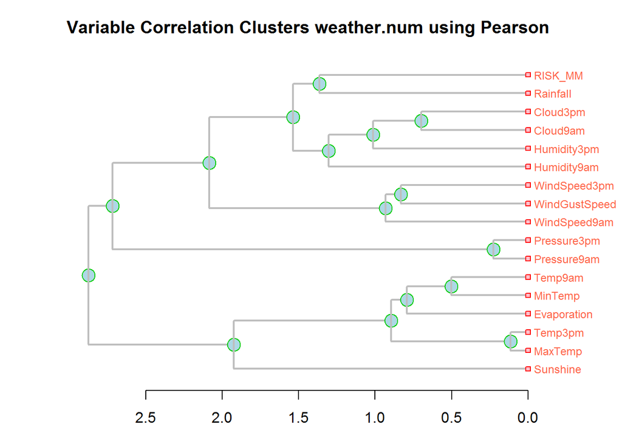

```
##
## Call:
## hclust(d = dist(cc), method = "average")
##
## Cluster method   : average
## Distance         : euclidean
## Number of objects: 17
```

```r
numvars <- lapply(weather,is.numeric)       # Find numeric variables in data set
weather.num <- na.omit(weather[,numvars==TRUE])

hcPlot <- function(data="numdata"){
  df <- eval(parse(text=data))
  cc <- cor(df,use="pairwise",method="pearson")
  hc <- hclust(dist(cc),method="average")
  dn <- as.dendrogram(hc)
  op <- par(mar = c(3, 4, 3, 4.29))
  plot(dn, horiz = TRUE, nodePar = list(col = 3:2, cex = c(2.0, 0.75),
                                        pch = 21:22, bg=  c("light blue", "pink"), lab.cex = 0.75,
                                        lab.col = "tomato"), edgePar = list(col = "gray", lwd = 2), xlab="Height")
  title(main=paste("Variable Correlation Clusters",data,"using Pearson",sep=" "),
        sub=paste(format(Sys.time(), "%Y-%b-%d %H:%M:%S"), Sys.info()["user"]))
  par(op)
  return(hc)
}

hcPlot(data="weather.num")           # Note: name of file must be in quotes!!
```

varclus, in the Hmisc package, does a hierarchical cluster analysis on variables, using the Hoeffding D statistic, squared Pearson or Spearman (the default) correlations, or proportion of observations for which two variables are both positive as similarity measures. The clustering is done by hclust().

```r
vClus <- varclus(as.matrix(numdata))
vClus
```

```
## varclus(x = as.matrix(numdata))
##
##
## Similarity matrix (Spearman rho^2)
##
##               MinTemp MaxTemp Rainfall Evaporation Sunshine WindGustSpeed
## MinTemp          1.00    0.58     0.04        0.42     0.01          0.04
## MaxTemp          0.58    1.00     0.02        0.50     0.23          0.01
## Rainfall         0.04    0.02     1.00        0.01     0.06          0.02
## Evaporation      0.42    0.50     0.01        1.00     0.16          0.09
## Sunshine         0.01    0.23     0.06        0.16     1.00          0.01
## WindGustSpeed    0.04    0.01     0.02        0.09     0.01          1.00
## WindSpeed9am     0.04    0.02     0.05        0.01     0.01          0.17
## WindSpeed3pm     0.01    0.05     0.01        0.00     0.00          0.46
## Humidity9am      0.05    0.11     0.06        0.30     0.27          0.13
## Humidity3pm      0.00    0.29     0.16        0.19     0.54          0.01
## Pressure9am      0.24    0.09     0.13        0.15     0.00          0.28
## Pressure3pm      0.23    0.14     0.08        0.16     0.00          0.25
## Cloud9am         0.05    0.03     0.09        0.02     0.50          0.00
## Cloud3pm         0.02    0.01     0.03        0.01     0.42          0.00
## Temp9am          0.84    0.77     0.00        0.51     0.08          0.06
## Temp3pm          0.53    0.98     0.02        0.48     0.25          0.00
## RISK_MM          0.05    0.00     0.07        0.00     0.20          0.03
##               WindSpeed9am WindSpeed3pm Humidity9am Humidity3pm
## MinTemp               0.04         0.01        0.05        0.00
## MaxTemp               0.02         0.05        0.11        0.29
## Rainfall              0.05         0.01        0.06        0.16
## Evaporation           0.01         0.00        0.30        0.19
## Sunshine              0.01         0.00        0.27        0.54
## WindGustSpeed         0.17         0.46        0.13        0.01
## WindSpeed9am          1.00         0.13        0.08        0.04
## WindSpeed3pm          0.13         1.00        0.06        0.00
## Humidity9am           0.08         0.06        1.00        0.24
## Humidity3pm           0.04         0.00        0.24        1.00
## Pressure9am           0.08         0.12        0.02        0.00
## Pressure3pm           0.03         0.09        0.02        0.00
## Cloud9am              0.04         0.00        0.16        0.32
## Cloud3pm              0.00         0.00        0.07        0.24
## Temp9am               0.01         0.00        0.17        0.08
## Temp3pm               0.03         0.06        0.11        0.33
```

[output cut: 106 more lines]

```
## Pressure3pm       354
## Cloud9am          354
## Cloud3pm          354
## Temp9am           354
## Temp3pm           354
## RISK_MM           354
##
## hclust results (method=complete)
##
##
## Call:
## hclust(d = as.dist(1 - x), method = method)
##
## Cluster method   : complete
## Number of objects: 17
```

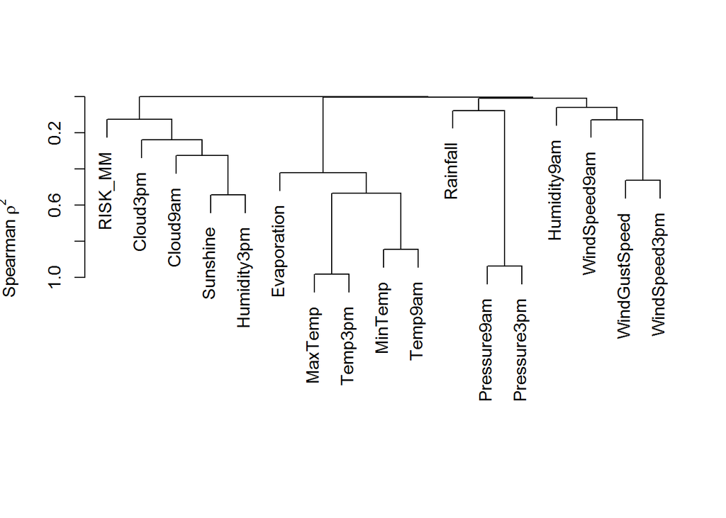

```r
plot(vClus)
```